# Notes on Ch 10: EDA

E4. Compare and contrast `coord_cartesian()` vs. `xlim()` or `ylim()` when zooming in on a histogram. What happens of you leave binwidth unset? What happens if you try and zoom so only half a bar shows?

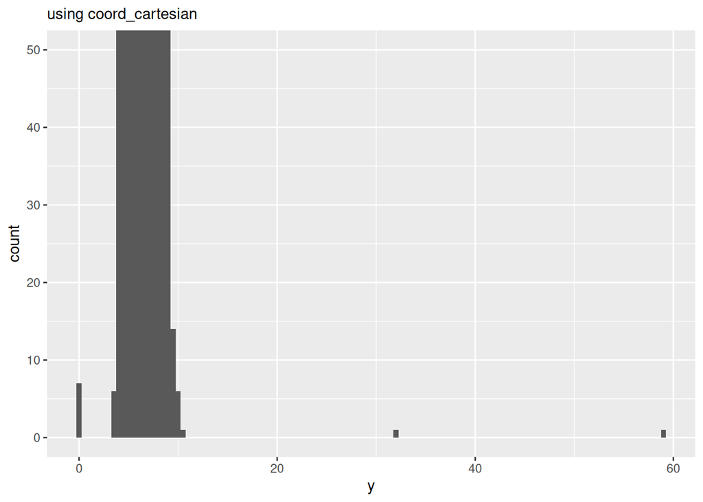

```r
ggplot(diamonds, aes(x = y)) +
  geom_histogram(binwidth = 0.5) +
  coord_cartesian(ylim = c(0, 50)) +
  labs(subtitle = "using coord_cartesian")
```

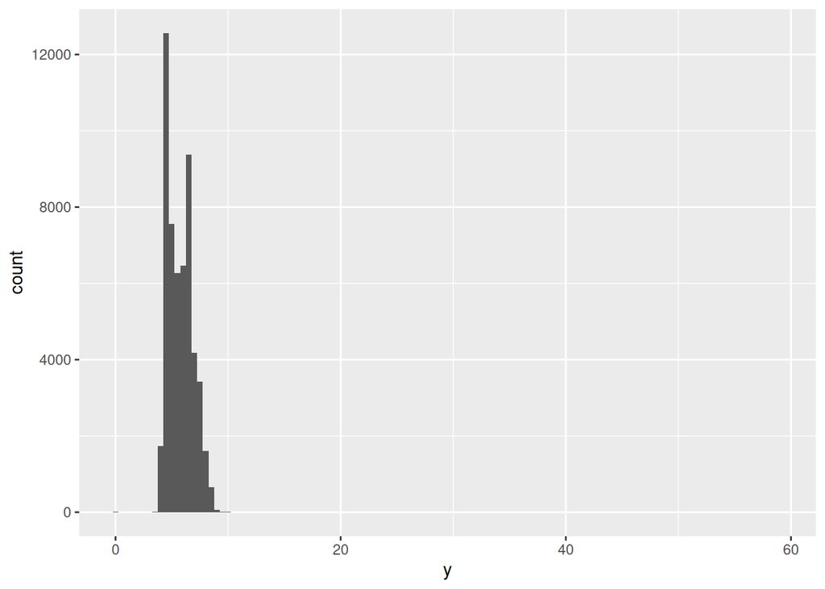

```r
ggplot(diamonds, aes(x = y)) +
  geom_histogram(binwidth = 0.5, ylim = c(0, 50))
```

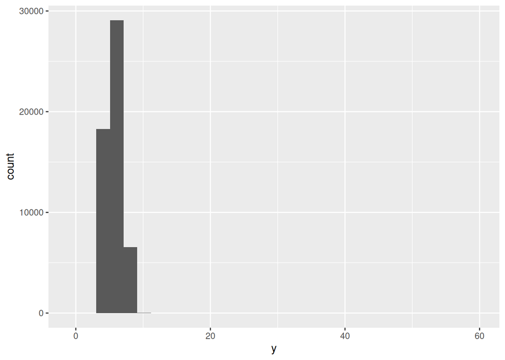

```r
ggplot(diamonds, aes(x = y)) +
  geom_histogram(ylim = c(0, 50))
```

- For zooming in on the graph, `coord_cartesian()` works, using the `ylim()` argument does not work since it removes the data outside of the limits.

## Unusual values

Option 1: dropping the row with strange values:

```r
diamonds2 <- diamonds |>
  filter(between(y, 3, 20))
```

Dropping the unusual values is not recommended since you are throwing away data – if there are many unusual values, you won’t have much data to work with.

Option 2: Replacing the unusual values with missing values:

```r
diamonds2 <- diamonds |>
  mutate(y = ifelse(y < 3 | y > 20, NA, y))
```

When plotting, ggplot does not show the missing values:

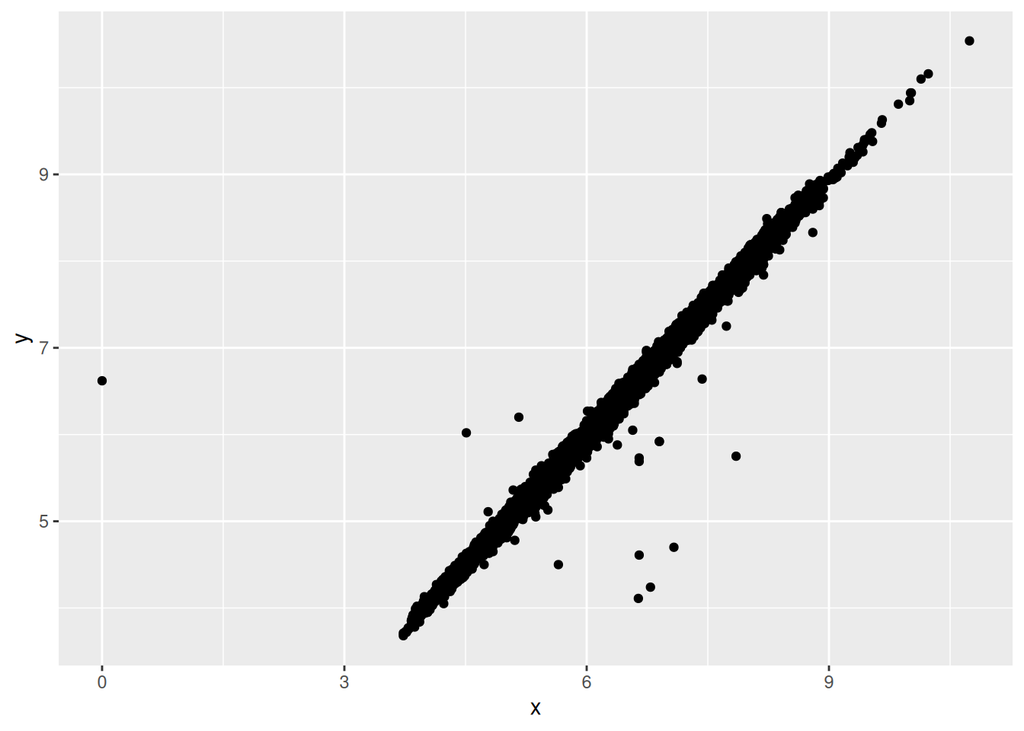

```r
ggplot(diamonds2, aes(x = x, y = y)) +
  geom_point()
```

Supressing the waring with `na.rm =TRUE` argument:

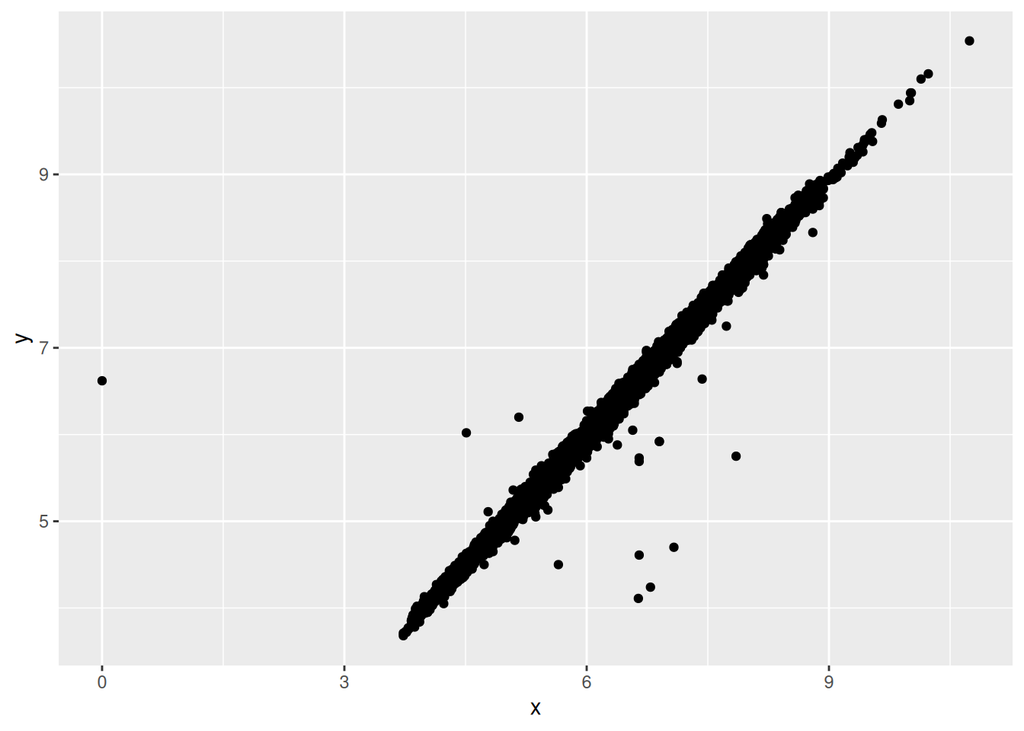

```r
ggplot(diamonds2, aes(x = x, y = y)) +
  geom_point(na.rm = TRUE)
```

It is also a good idea to plot the missing values to understand the difference between them and the values which are not missing:

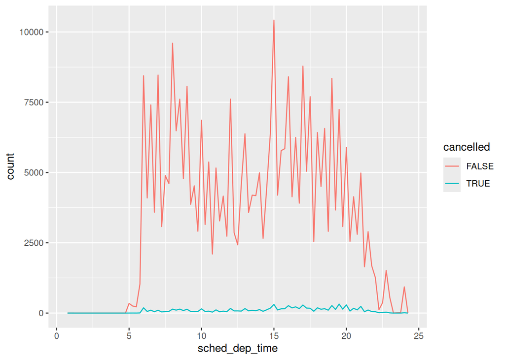

```r
nycflights13::flights |>
  mutate(
    cancelled = is.na(dep_time),
    sched_hour = sched_dep_time %/% 100,
    sched_min = sched_dep_time %% 100,
    sched_dep_time = sched_hour + (sched_min / 60)
  ) |>
  ggplot(aes(x = sched_dep_time)) +
  geom_freqpoly(aes(color = cancelled), binwidth = 1/4)
```

## Exercises

E1. What happens to missing values in a histogram? What happens to missing values in a bar chart? Why is there a difference in how missing values are handled in histograms and bar charts?

Ans.

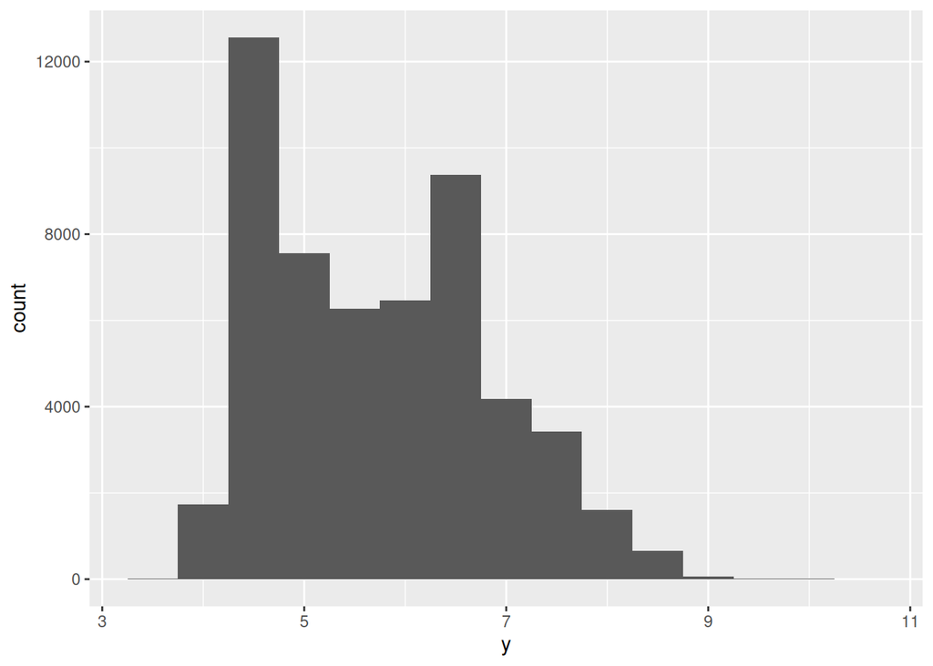

```r
ggplot(diamonds2, aes(x = y)) +
  geom_histogram(binwidth = 0.5)
```

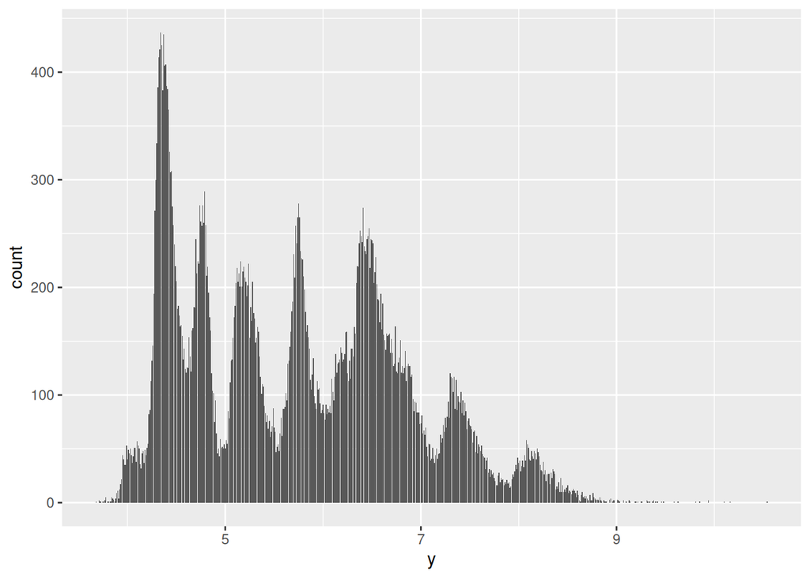

```r
ggplot(diamonds2, aes(x = y)) +
  geom_bar()
```

`geom_histogram()` and `geom_bar()` removed the missing values.

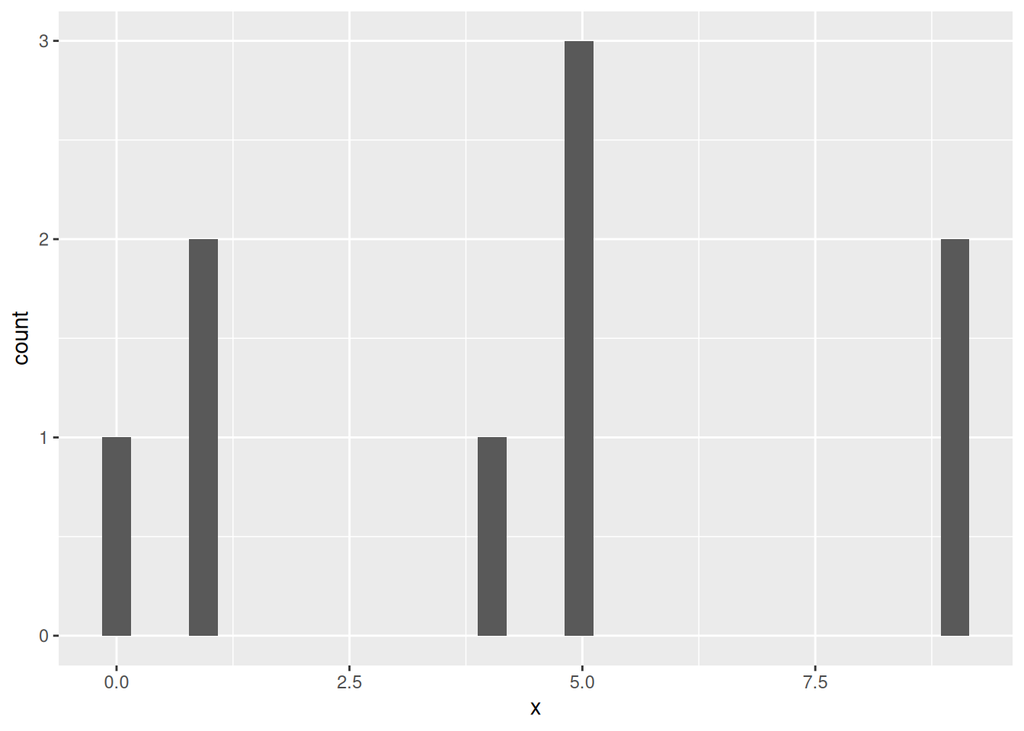

```r
x <-  c(9, 9, 4, 5, 1, 0, 5, 5, 1, NA)
df <- data.frame(x)

ggplot(df, aes(x = x)) +
  geom_histogram()
```

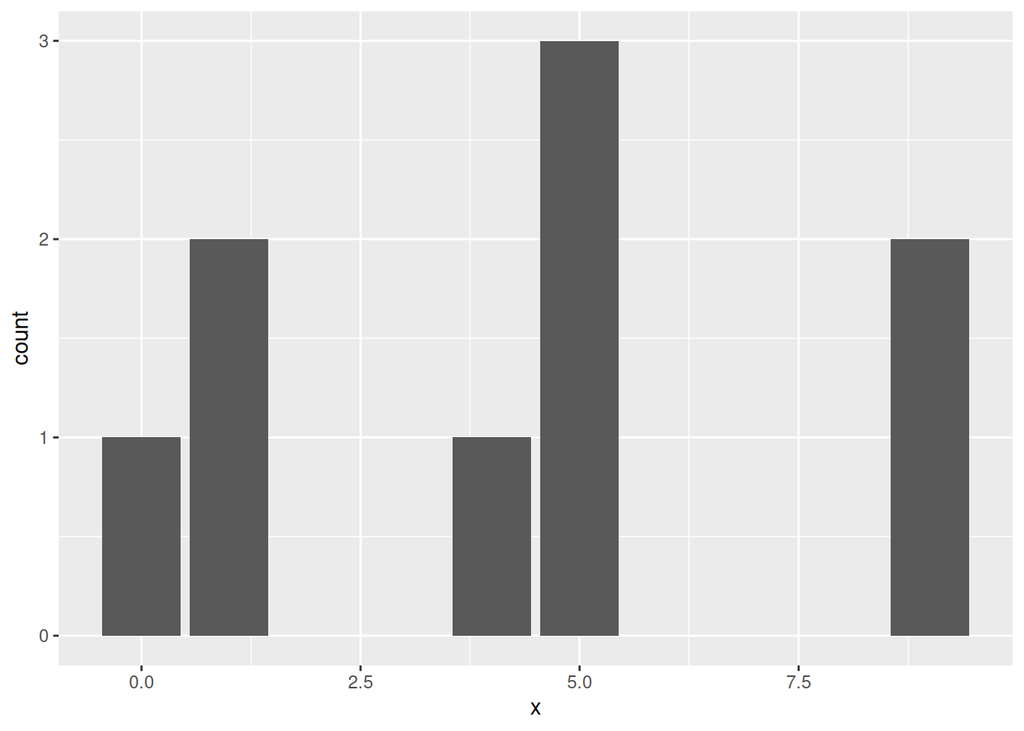

```r
ggplot(df, aes(x = x)) +
  geom_bar()
```

I think that in previous versions of R, missing values are treated differently by `geom_histogram()` and `geom_bar()`

E2. What does `na.rm = TRUE` do in `mean()` and `sum()`?

Ans. The argument removes `NA`s first before performing the mean and sum operations, respectively.

E3. Recreate the frequency plot of `scheduled_dep_time` colored by whether the flight was cancelled or not. Also facet by the cancelled variable. Experiment with different values of the scales variable in the faceting function to mitigate the effect of more non-cancelled flights than cancelled flights.

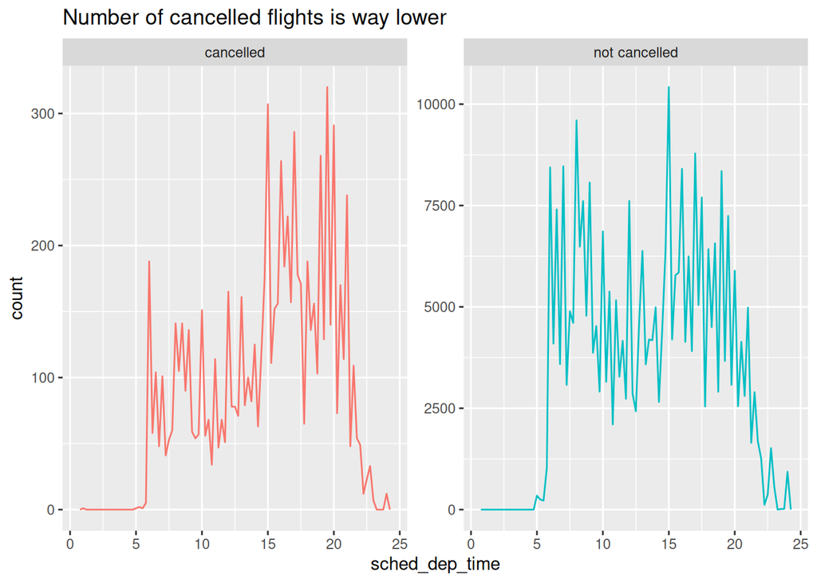

```r
nycflights13::flights |>
  mutate(
    cancelled = is.na(dep_time),
    cancelled = ifelse(cancelled == T, "cancelled", "not cancelled"),
    sched_hour = sched_dep_time %/% 100,
    sched_min = sched_dep_time %% 100,
    sched_dep_time = sched_hour + (sched_min / 60)
  ) |>
  ggplot(aes(x = sched_dep_time)) +
  geom_freqpoly(aes(color = cancelled), binwidth = 1/4, show.legend = FALSE) +
  facet_wrap(~ cancelled, scales = "free_y") +
  labs(
    title = "Number of cancelled flights is way lower"
  )
```

## Covariation

- **Covariation** is the tendency for the values of two variables to vary together in a related way.
- The best way to spot this is through visualization.

Example:

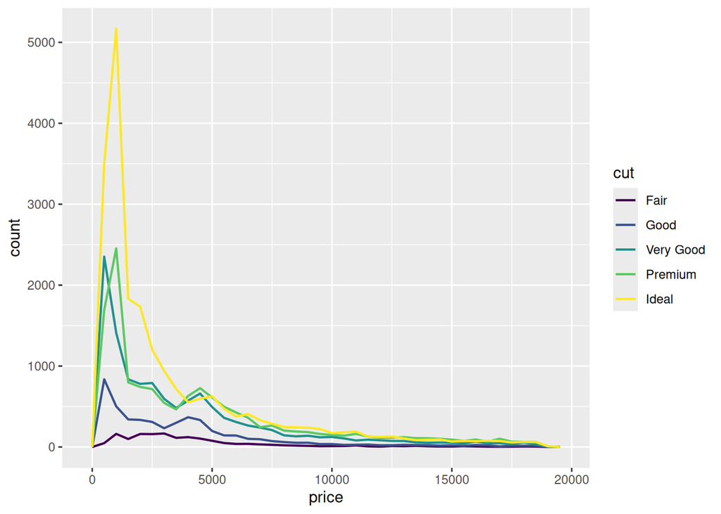

```r
ggplot(diamonds, aes(x = price)) +
  geom_freqpoly(
    aes(color = cut),
    binwidth = 500, linewidth = 0.75
  )
```

- The default appearance of `geom_freqpoly()` is not that useful here because it shows th overall count. - To make the comparison easier, we can display the *density* instead of count.

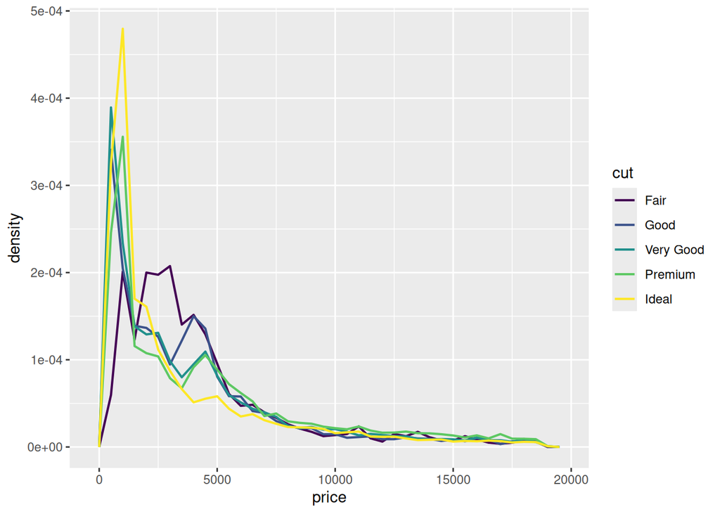

```r
ggplot(diamonds, aes(
  x = price, y = after_stat(density)
)) +
  geom_freqpoly(
    aes(color = cut),
    binwidth = 500,
    linewidth = 0.75
  )
```

Note: density is mapped to y, but since `density` is not a variable in the dataset, it must be calculated first – the `after_stat()` function was used for that.

In the plot, it looks like the diamond with the lowest quality (fair) has the highest prices. Is this correct or is this due to the complexity of frequency plots? Perhaps a simpler plot is necessary.

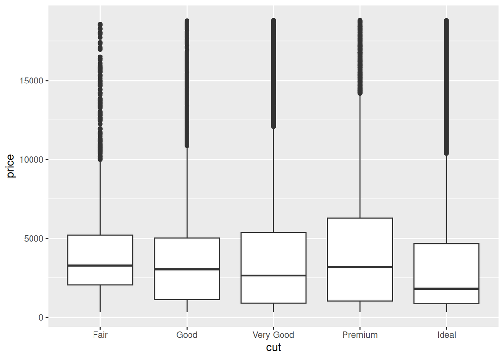

```r
ggplot(diamonds, aes(x = cut, y = price)) +
  geom_boxplot()
```

Note: The varible `cut` is an ordered factor in the data, i.e. Fair -> Good -> Very Good -> Premium… If the variable is not an ordered factor, the order can be assigned using the function `fct_reorder()`.

Another Example:

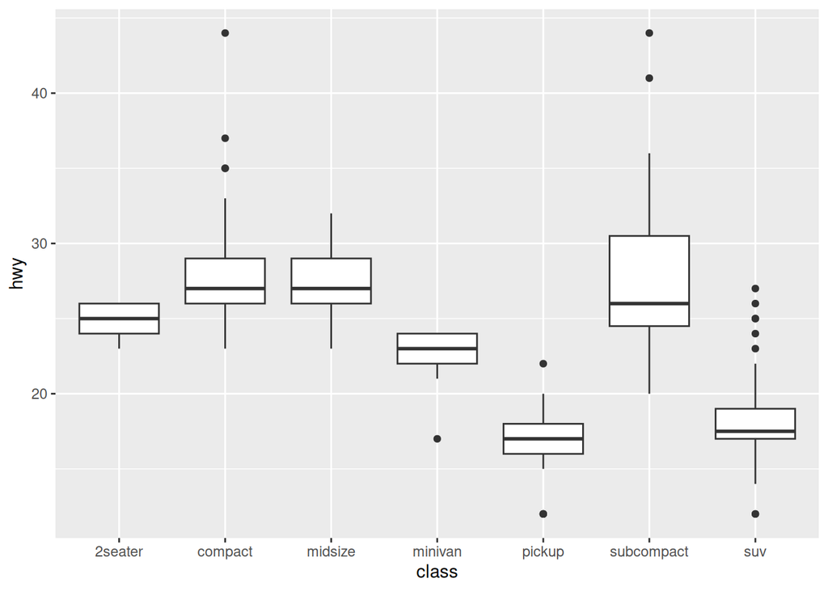

```r
ggplot(mpg, aes(x = class, y = hwy)) +
  geom_boxplot()
```

The variable `class` is not ordered, in this case. We can set an order to `class` like this:

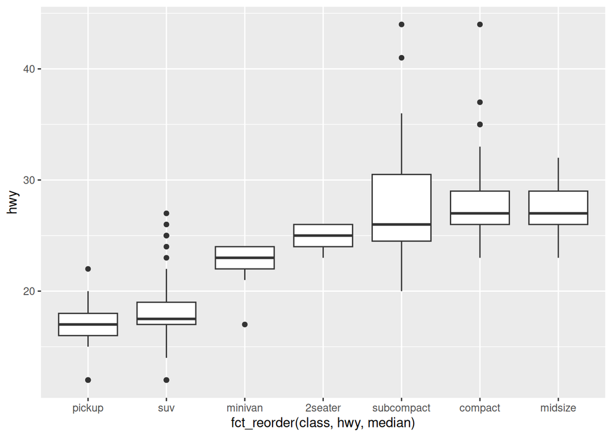

```r
ggplot(mpg, aes(
  x = fct_reorder(class, hwy, median),
  y = hwy
)) +
  geom_boxplot()
```

Rotated version:

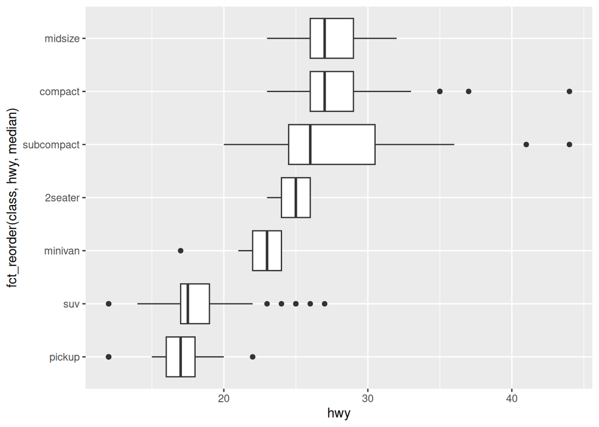

```r
ggplot(mpg, aes(
  x = hwy,
  y = fct_reorder(class, hwy, median)
)) +
  geom_boxplot()
```

## #xercises

E1. Use what you’ve learned to improve the visualization of the departure times of cancelled vs. non-cancelled flights.

E2. Based on EDA, what variable in the `diamonds` dataset appears to be most important for predicting the price of a diamond? How is that variable correlated with cut? Why does the combination of those two relationships lead to lower quality diamonds being more expensive?

E3. Instead of exchanging the x and y variables, add `coord_flip()` as a new layer to the vertical boxplot to create a horizontal one. How does this compare to exchanging the variables?

Ans.

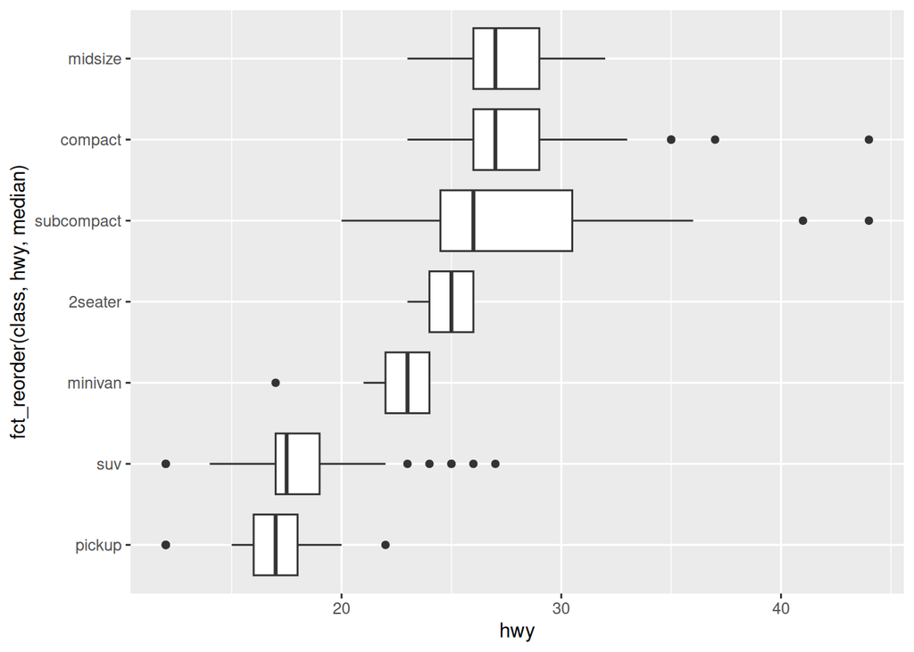

```r
ggplot(mpg, aes(
  x = fct_reorder(class, hwy, median),
  y = hwy
)) +
  geom_boxplot() +
  coord_flip()
```

The result is exactly similar.

E4. One problem with boxplots is that they were developed in an era of much smaller datasets and tend to display a prohibitively large number of “outlying values”. One approach to remedy this problem is the letter value plot. Install the `lvplot` package, and try using `geom_lv()` to display the distribution of price vs. cut. What do you learn? How do you interpret the plots?

E5. Create a visualization of diamond prices vs. a categorical variable from the diamonds dataset using geom_violin(), then a faceted geom_histogram(), then a colored `geom_freqpoly()`, and then a colored geom_density(). Compare and contrast the four plots. What are the pros and cons of each method of visualizing the distribution of a numerical variable based on the levels of a categorical variable?

Ans.

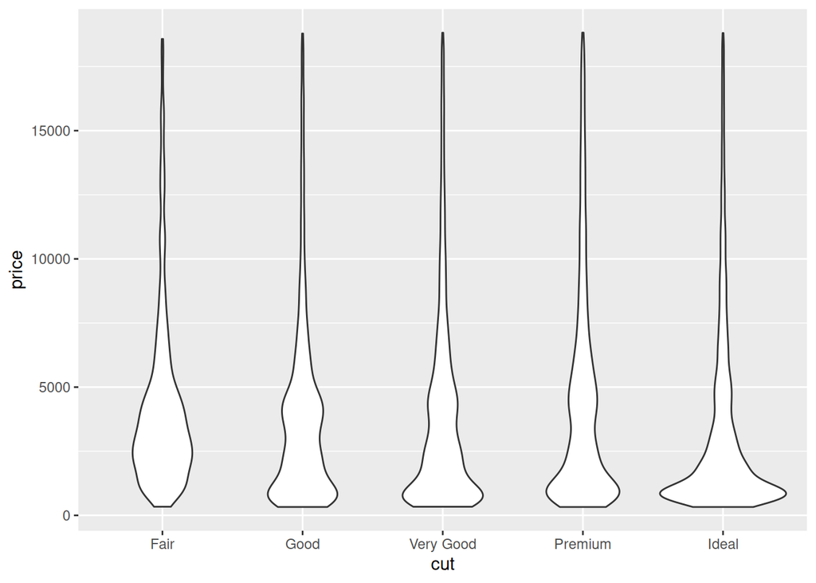

```r
p <- ggplot(diamonds, aes(
  x = cut, y = price
))

p + geom_violin()
```

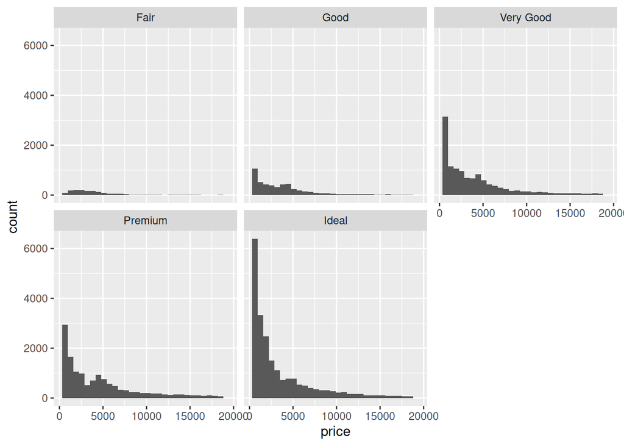

```r
ggplot(diamonds, aes(x = price)) +
  geom_histogram() +
  facet_wrap(~ cut)
```

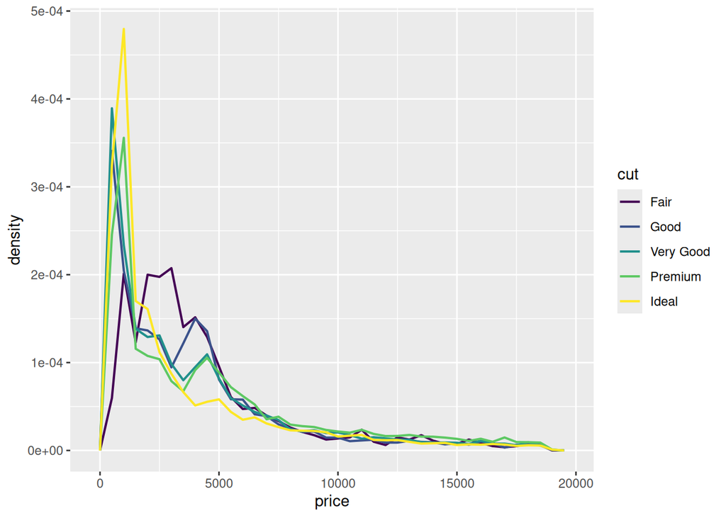

```r
ggplot(diamonds, aes(x = price, y = after_stat(density))) +
  geom_freqpoly(aes(color = cut), binwidth = 500, linewidth = 0.75)
```

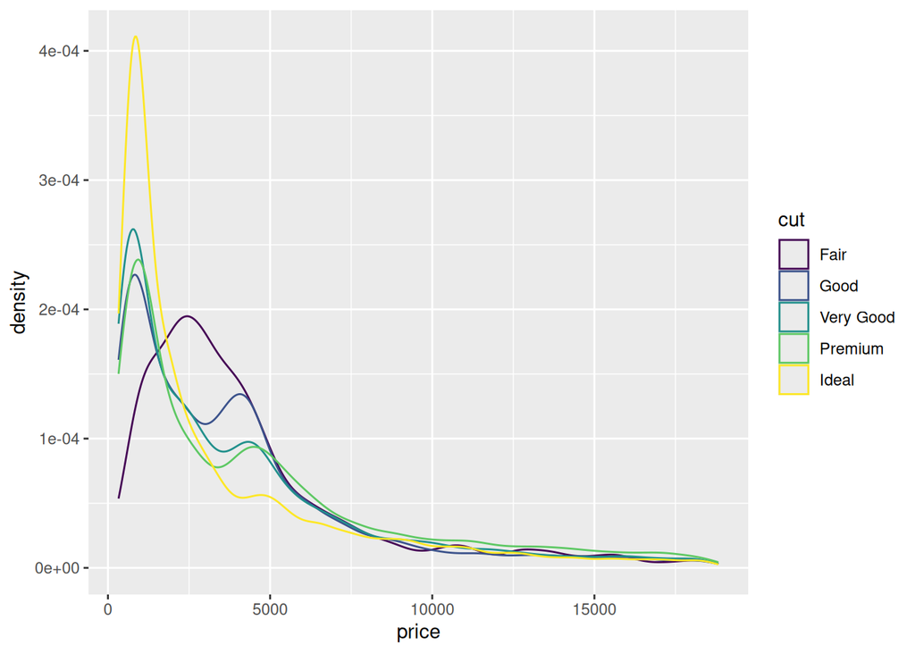

```r
ggplot(diamonds, aes(x = price)) +
  geom_density(aes(color = cut))
```

E6. If you have a small dataset, it’s sometimes useful to use `geom_jitter()` to avoid overplotting to more easily see the relationship between a continuous and categorical variable. The `ggbeeswarm` package provides a number of methods similar to `geom_jitter()`. List them and briefly describe what each one does.

Ans. `geom_jitter()` a random noise to the data to avoid overplotting. In `ggbeeswarm`, commonly used in column-wise scatterplots arrange the data points in such a way that a bee-swarm-like pattern appears. This is also done to avoid overplotting.